# Insert chapter 2 title here

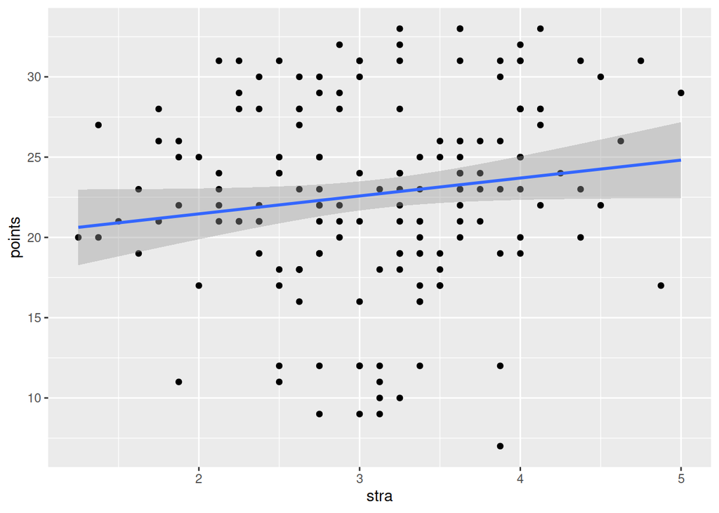

```r
qplot(stra, points, data = learning2014) + geom_smooth(method = "lm")
```

```r
qplot(surf, points, data = learning2014) + geom_smooth(method = "lm")
qplot(surf, points, data = learning2014) + geom_smooth(method = "lm")
# fit a linear model
p_att_model <- lm(points ~ attitude, data = learning2014)
p_stra_model <- lm(points ~ stra, data = learning2014)
p_surf_model <- lm(points ~ surf, data = learning2014)

# print out a summary of the model
summary(p_att_model)
```

[output not shown]

```
##
## Call:
## lm(formula = points ~ attitude, data = learning2014)
##
## Residuals:
##      Min       1Q   Median       3Q      Max
## -16.9763  -3.2119   0.4339   4.1534  10.6645
##
## Coefficients:
##             Estimate Std. Error t value Pr(>|t|)
## (Intercept)  11.6372     1.8303   6.358 1.95e-09 ***
## attitude      3.5255     0.5674   6.214 4.12e-09 ***
## ---
## Signif. codes:  0 '***' 0.001 '**' 0.01 '*' 0.05 '.' 0.1 ' ' 1
##
## Residual standard error: 5.32 on 164 degrees of freedom
## Multiple R-squared:  0.1906, Adjusted R-squared:  0.1856
## F-statistic: 38.61 on 1 and 164 DF,  p-value: 4.119e-09
```

```r
summary(p_stra_model)
```

```
##
## Call:
## lm(formula = points ~ stra, data = learning2014)
##
## Residuals:
##      Min       1Q   Median       3Q      Max
## -16.5581  -3.8198   0.1042   4.3024  10.1394
##
## Coefficients:
##             Estimate Std. Error t value Pr(>|t|)
## (Intercept)   19.233      1.897  10.141   <2e-16 ***
## stra           1.116      0.590   1.892   0.0603 .
## ---
## Signif. codes:  0 '***' 0.001 '**' 0.01 '*' 0.05 '.' 0.1 ' ' 1
##
## Residual standard error: 5.849 on 164 degrees of freedom
## Multiple R-squared:  0.02135,    Adjusted R-squared:  0.01538
## F-statistic: 3.578 on 1 and 164 DF,  p-value: 0.06031
```

```r
summary(p_surf_model)
```

```
##
## Call:
## lm(formula = points ~ surf, data = learning2014)
##
## Residuals:
##      Min       1Q   Median       3Q      Max
## -14.6539  -3.3744   0.3574   4.4734  10.2234
##
## Coefficients:
##             Estimate Std. Error t value Pr(>|t|)
## (Intercept)  27.2017     2.4432  11.134   <2e-16 ***
## surf         -1.6091     0.8613  -1.868   0.0635 .
## ---
## Signif. codes:  0 '***' 0.001 '**' 0.01 '*' 0.05 '.' 0.1 ' ' 1
##
## Residual standard error: 5.851 on 164 degrees of freedom
## Multiple R-squared:  0.02084,    Adjusted R-squared:  0.01487
## F-statistic:  3.49 on 1 and 164 DF,  p-value: 0.06351
```

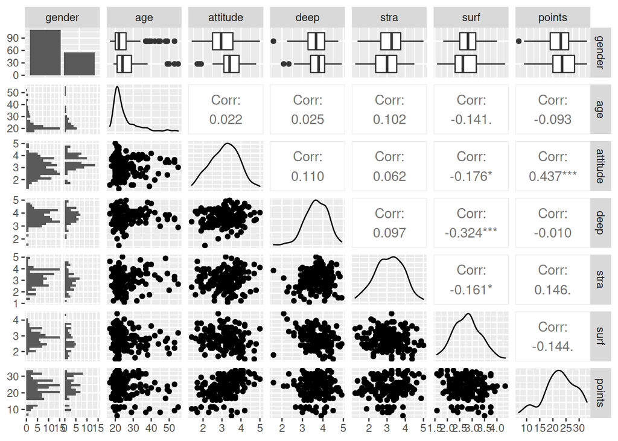

```r
ggpairs(learning2014, lower = list(combo = wrap("facethist", bins = 20)))
```

```r
my_model2 <- lm(points ~ attitude + stra + surf, data = learning2014)

summary(my_model2)
```

```
##
## Call:
## lm(formula = points ~ attitude + stra + surf, data = learning2014)
##
## Residuals:
##      Min       1Q   Median       3Q      Max
## -17.1550  -3.4346   0.5156   3.6401  10.8952
##
## Coefficients:
##             Estimate Std. Error t value Pr(>|t|)
## (Intercept)  11.0171     3.6837   2.991  0.00322 **
## attitude      3.3952     0.5741   5.913 1.93e-08 ***
## stra          0.8531     0.5416   1.575  0.11716
## surf         -0.5861     0.8014  -0.731  0.46563
## ---
## Signif. codes:  0 '***' 0.001 '**' 0.01 '*' 0.05 '.' 0.1 ' ' 1
##
## Residual standard error: 5.296 on 162 degrees of freedom
## Multiple R-squared:  0.2074, Adjusted R-squared:  0.1927
## F-statistic: 14.13 on 3 and 162 DF,  p-value: 3.156e-08
```

The Multiple R-squared is 0.1906 for attitude as explanatory variable for points. The fitted line shows that points rise with higher attitude, points, so they do have a positive correlation.

The other variables I chose to look at were stra and surf. Neither one has a major correlation with points, with surf having a slight but not significant correlation, and strat a slight positive one.

*Using a summary of your fitted model, explain the relationship between the chosen explanatory variables and the target variable (interpret the model parameters). Explain and interpret the multiple R-squared of the model. (0-3 points)*